# A1

Alvaro Rodriguez Mujica

14/9/2021

# Tarea 1

## Ejercicio 0

### 1)

Crea un vector dado_honesto con 100 numeros usando sample()

```r
(dado_honesto <- sample(1:6, 100, replace = TRUE))
```

```
##   [1] 4 4 2 4 3 5 3 5 6 4 4 4 2 2 4 4 2 6 5 5 5 5 1 3 1 6 5 2 1 2 2 4 5 1 6 4 6
##  [38] 5 4 2 4 3 2 3 4 1 5 2 3 5 5 5 1 3 6 3 1 5 1 5 6 2 6 1 3 6 3 3 3 6 5 5 6 6
##  [75] 3 1 4 6 5 2 6 5 6 2 6 4 5 3 4 2 1 6 4 6 4 4 1 6 1 3
```

Frecuencia Absoluta y Relativa con “table”

```r
(df1 <- table(dado_honesto))
```

```
## dado_honesto
##  1  2  3  4  5  6
## 13 14 15 19 20 19
```

```r
(prop.table(df1))
```

```
## dado_honesto
##    1    2    3    4    5    6
## 0.13 0.14 0.15 0.19 0.20 0.19
```

Frecuencia Absoluta con dplyr

```r
library(tidyverse)
df2 <- data.frame(dado_honesto)
(df2 %>%
  count(dado_honesto))
```

```
##   dado_honesto  n
## 1            1 13
## 2            2 14
## 3            3 15
## 4            4 19
## 5            5 20
## 6            6 19
```

### 2)

```r
(dado_cargado <- sample(1:6, 100, replace = TRUE, prob = c(1/15,1/15,1/15,1/15,1/15,4/6 )))
```

```
##   [1] 3 6 6 6 2 6 2 6 6 6 6 6 1 3 6 6 6 6 6 6 6 6 4 6 6 6 6 3 3 6 2 6 6 1 6 6 6
##  [38] 6 4 6 6 6 6 4 6 3 6 5 6 4 6 6 2 6 5 6 6 6 4 3 6 6 6 6 4 6 6 6 5 6 6 6 6 6
##  [75] 3 6 6 5 1 6 6 6 3 6 6 6 6 6 6 2 6 6 6 6 6 2 6 6 1 6
```

Frecuencias Absolutas y Relativas con “table”

```r
(df3 <- table(dado_cargado))
```

```
## dado_cargado
##  1  2  3  4  5  6
##  4  6  8  6  4 72
```

```r
(prop.table(df3))
```

```
## dado_cargado
##    1    2    3    4    5    6
## 0.04 0.06 0.08 0.06 0.04 0.72
```

Frecuencia Absoluta con dplyr

```r
df4 <- data.frame(dado_cargado)
(df4 %>%
  count(dado_cargado))
```

```
##   dado_cargado  n
## 1            1  4
## 2            2  6
## 3            3  8
## 4            4  6
## 5            5  4
## 6            6 72
```

### 3)

```r
(v1 <- c(rep(4, times = 4), rep(3, times = 4), rep(2, times = 4), rep(1, times = 4)))
```

```
##  [1] 4 4 4 4 3 3 3 3 2 2 2 2 1 1 1 1
```

```r
(v2 <- c(rep(1, times = 1), rep(2, times = 2), rep(3, times = 3), rep(4, times = 4), rep(5, times = 5)))
```

```
##  [1] 1 2 2 3 3 3 4 4 4 4 5 5 5 5 5
```

```r
(v3 <- rep(c(1,2,3,4), times = 4))
```

```
##  [1] 1 2 3 4 1 2 3 4 1 2 3 4 1 2 3 4
```

### 4)

```r
mpg2 <- mpg %>%
  select(starts_with("c")) %>%
  filter(class == "pickup")

(mpg2)
```

```
## # A tibble: 33 x 3
##      cyl   cty class
##    <int> <int> <chr>
##  1     6    15 pickup
##  2     6    14 pickup
##  3     6    13 pickup
##  4     6    14 pickup
##  5     8    14 pickup
##  6     8    14 pickup
##  7     8     9 pickup
##  8     8    11 pickup
##  9     8    11 pickup
## 10     8    12 pickup
## # ... with 23 more rows
```

### 5)

```r
library(haven)
census <- read_dta("Data/census.dta")
```

Poblaciones totales de las regiones censales

```r
(census2 <- census %>%
   group_by(region) %>%
   summarize(total_pop = sum(pop)))
```

```
## # A tibble: 4 x 2
##        region total_pop
##     <dbl+lbl>     <dbl>
## 1 1 [NE]       49135283
## 2 2 [N Cntrl]  58865670
## 3 3 [South]    74734029
## 4 4 [West]     43172490
```

Diagrama de barras

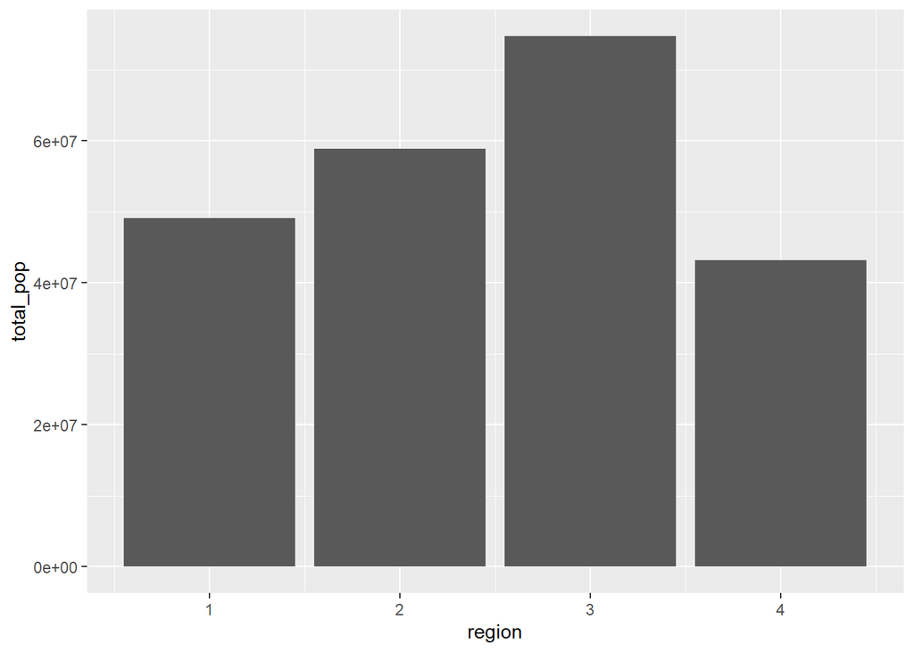

```r
library(ggplot2)
ggplot(census2, mapping = aes(x = region, y = total_pop)) +
  geom_bar(stat = "identity")
```

Orden de los estados por número de población (de mayor a menor)

```r
arrange(census, desc(pop))
```

```
## # A tibble: 50 x 12
##    state       region    pop poplt5 pop5_17 pop18p pop65p popurban medage  death
##    <chr>    <dbl+lbl>  <dbl>  <dbl>   <dbl>  <dbl>  <dbl>    <dbl>  <dbl>  <dbl>
##  1 Califor~ 4 [West]  2.37e7 1.71e6 4680558 1.73e7 2.41e6 21607606   29.9 186428
##  2 New York 1 [NE]    1.76e7 1.14e6 3551938 1.29e7 2.16e6 14858068   31.9 171769
##  3 Texas    3 [South] 1.42e7 1.17e6 3137045 9.92e6 1.37e6 11333017   28.2 108019
##  4 Pennsyl~ 1 [NE]    1.19e7 7.47e5 2375838 8.74e6 1.53e6  8220851   32.1 123261
##  5 Illinois 2 [N Cnt~ 1.14e7 8.42e5 2400796 8.18e6 1.26e6  9518039   29.9 102230
##  6 Ohio     2 [N Cnt~ 1.08e7 7.87e5 2307170 7.70e6 1.17e6  7918259   29.9  98268
##  7 Florida  3 [South] 9.75e6 5.70e5 1789412 7.39e6 1.69e6  8212385   34.7 104190
##  8 Michigan 2 [N Cnt~ 9.26e6 6.85e5 2066873 6.51e6 9.12e5  6551551   28.8  75102
##  9 New Jer~ 1 [NE]    7.36e6 4.63e5 1527572 5.37e6 8.60e5  6557377   32.2  68762
## 10 N. Caro~ 3 [South] 5.88e6 4.04e5 1253659 4.22e6 6.03e5  2822852   29.6  48426
## # ... with 40 more rows, and 2 more variables: marriage <dbl>, divorce <dbl>
```

```r
census3 <- census %>%
  mutate(census, prop_mayor = pop65p / pop) %>%
  select(medage, prop_mayor) %>%
  arrange(medage)
head(census3, 10)
```

```
## # A tibble: 10 x 2
##    medage prop_mayor
##     <dbl>      <dbl>
##  1   24.2     0.0748
##  2   26.1     0.0287
##  3   27.1     0.0792
##  4   27.4     0.0961
##  5   27.4     0.0890
##  6   27.6     0.0992
##  7   27.7     0.115
##  8   28.1     0.0920
##  9   28.2     0.0964
## 10   28.3     0.123
```

Histograma de los valores de medage y con la curva de densidad de la variable superpuesta

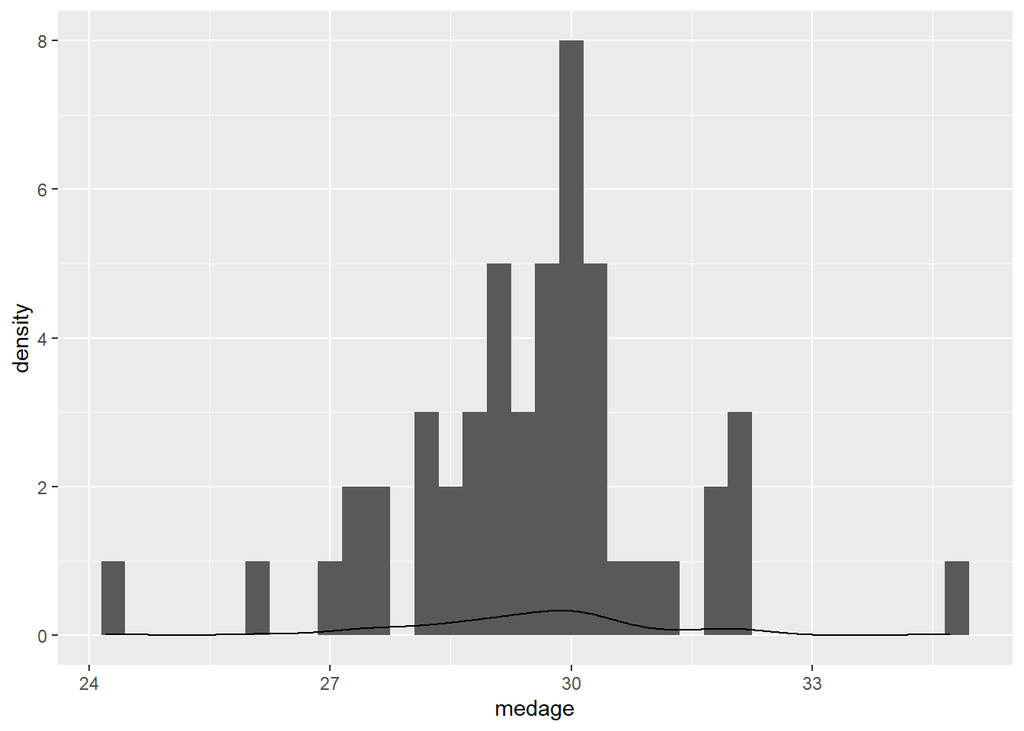

```r
(ggplot(data = census) +
  geom_histogram(mapping = aes(medage), binwidth = 0.3) +
  geom_density(mapping = aes(medage)))
```

## Ejercicio 1

Carga cholesterol.csv

```r
chlstrl = read.csv(file = "./data/cholesterol.csv")
view(chlstrl)
```

El data.frame chlstrl tiene 403 observaciones en 7 variables. Las siete variables son: - chol: variable cuantitativa - age: variable cuantitativa - gender: variable categórica - height: variable cuantitativa - weight: variable cuantitativa - waist: variable cuantitativa - hip: variable cuantitativa

Vemos si hay datos ausentes en cada una de las columnas de la tabla

```r
cbind(
  lapply(
    lapply(chlstrl, is.na)
    , sum)
  )
```

```
##        [,1]
## chol   1
## age    0
## gender 0
## height 5
## weight 1
## waist  2
## hip    2
```

Vemos que hay 1 dato ausente en la columna de chol, 5 en la columna de height, 1 en la de weight, 2 en la de waist y 2 en la de hip. Vamos a localizar exactamente donde se encuentran los datos ausentes.

```r
which(is.na(chlstrl$chol))
```

```
## [1] 28
```

```r
which(is.na(chlstrl$height))
```

```
## [1]  64  87 196 232 318
```

```r
which(is.na(chlstrl$weight))
```

```
## [1] 162
```

```r
which(is.na(chlstrl$waist))
```

```
## [1] 337 394
```

```r
which(is.na(chlstrl$hip))
```

```
## [1] 337 394
```

Vamos a empezar con el análisis numérico de cada una de las variables empezando por las varibles cuantitativas:

1. chol:

```r
min(chlstrl$chol, na.rm = TRUE)
```

```
## [1] 78
```

```r
max(chlstrl$chol, na.rm = TRUE)
```

```
## [1] 443
```

```r
mean(chlstrl$chol, na.rm = TRUE)
```

```
## [1] 207.8458
```

```r
median(chlstrl$chol, na.rm = TRUE)
```

```
## [1] 204
```

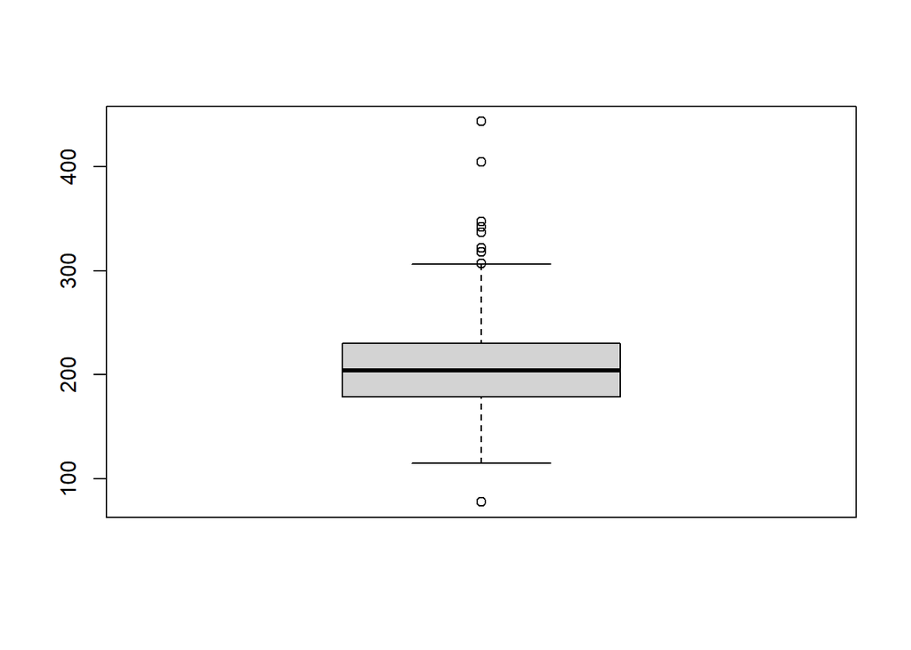

```r
bxp_chol = boxplot(chlstrl$chol)
```

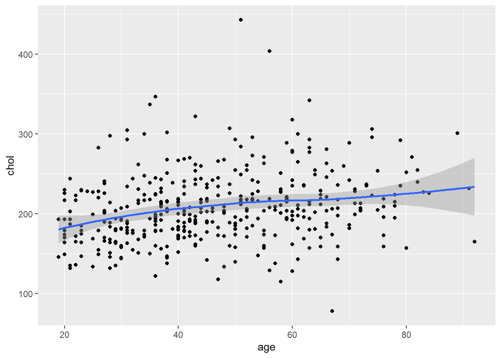

```r
ggplot(data = chlstrl) +
  geom_point(mapping = aes(x = age, y = chol)) +
  geom_smooth(mapping = aes(x = age, y = chol))
```

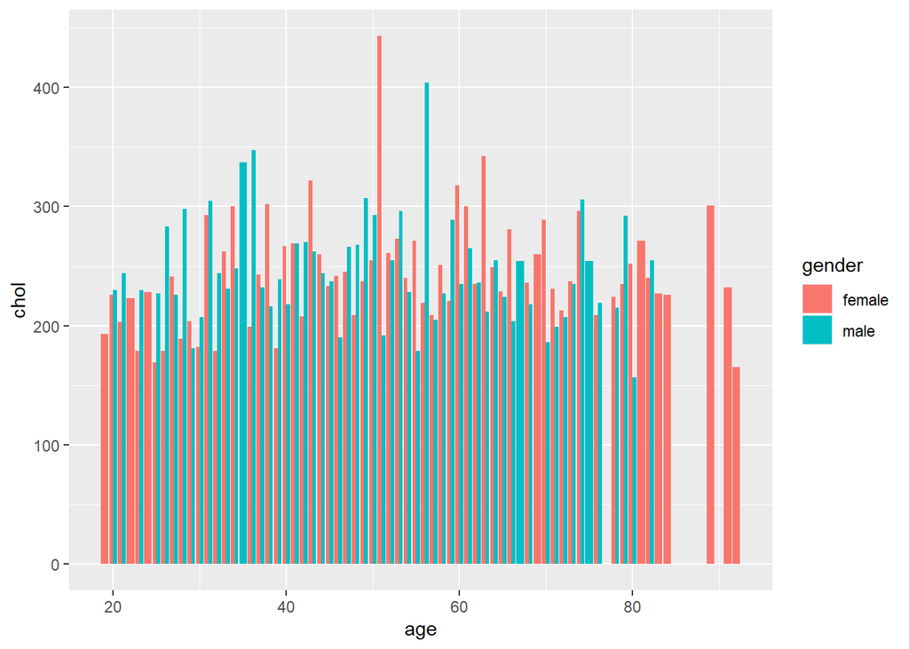

```r
ggplot(data = chlstrl, mapping = aes(x = age, y = chol, fill = gender)) +
  geom_bar(position = position_dodge(), stat = "identity", na.rm = TRUE)
```

2. age:

```r
min(chlstrl$age, na.rm = TRUE)
```

```
## [1] 19
```

```r
max(chlstrl$age, na.rm = TRUE)
```

```
## [1] 92
```

```r
mean(chlstrl$age, na.rm = TRUE)
```

```
## [1] 46.85112
```

```r
median(chlstrl$age, na.rm = TRUE)
```

```
## [1] 45
```

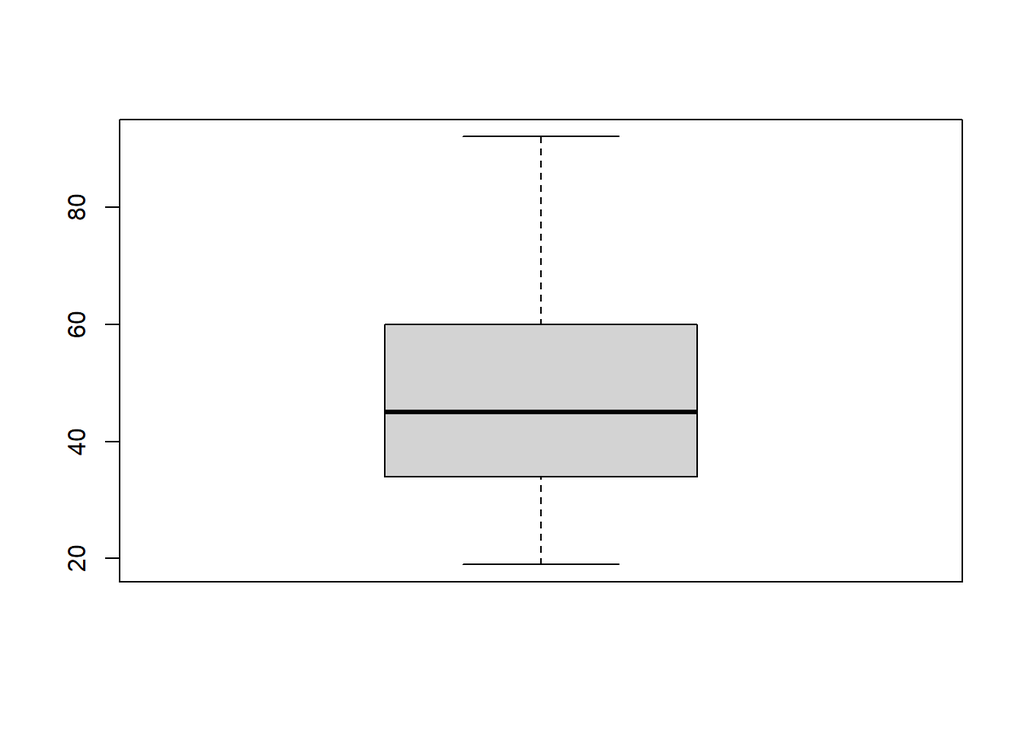

```r
bxp_age = boxplot(chlstrl$age)
```

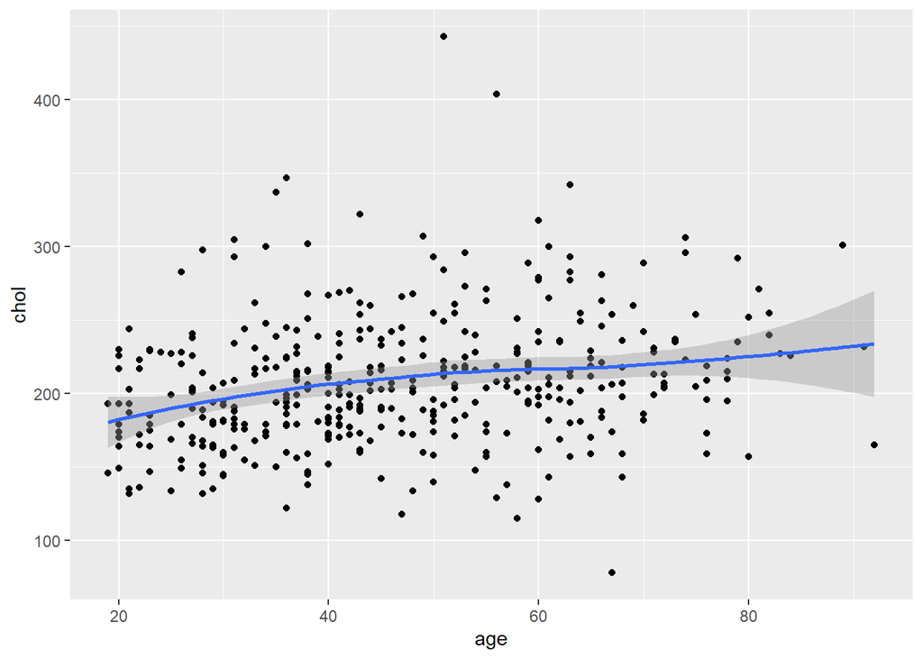

```r
ggplot(data = chlstrl) +
  geom_point(mapping = aes(x = age, y = chol)) +
  geom_smooth(mapping = aes(x = age, y = chol))
```

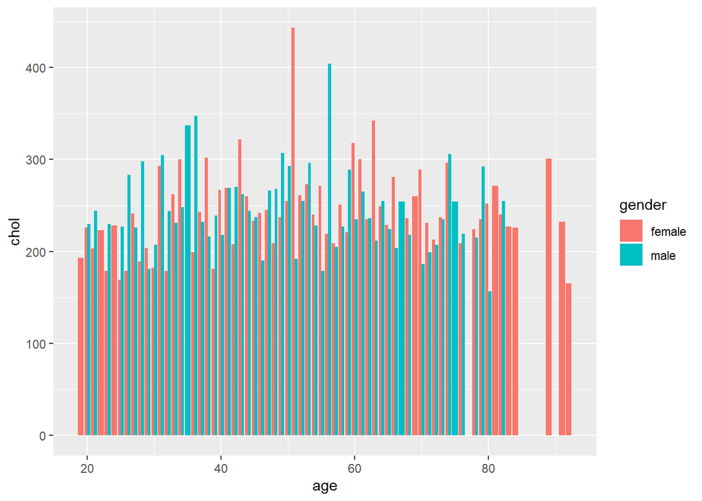

```r
ggplot(data = chlstrl, mapping = aes(x = age, y = chol, fill = gender)) +
  geom_bar(position = position_dodge(), stat = "identity", na.rm = TRUE)
```

3. height:

```r
min(chlstrl$height, na.rm = TRUE)
```

```
## [1] 52
```

```r
max(chlstrl$height, na.rm = TRUE)
```

```
## [1] 76
```

```r
mean(chlstrl$height, na.rm = TRUE)
```

```
## [1] 66.0201
```

```r
median(chlstrl$height, na.rm = TRUE)
```

```
## [1] 66
```

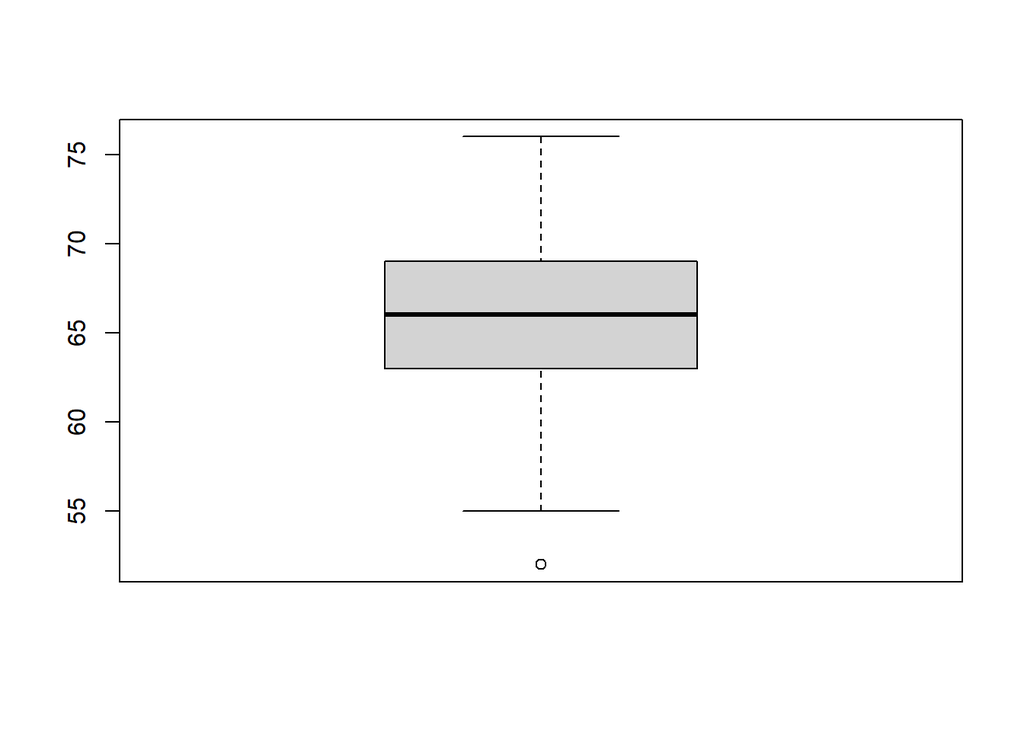

```r
bxp_height = boxplot(chlstrl$height)
```

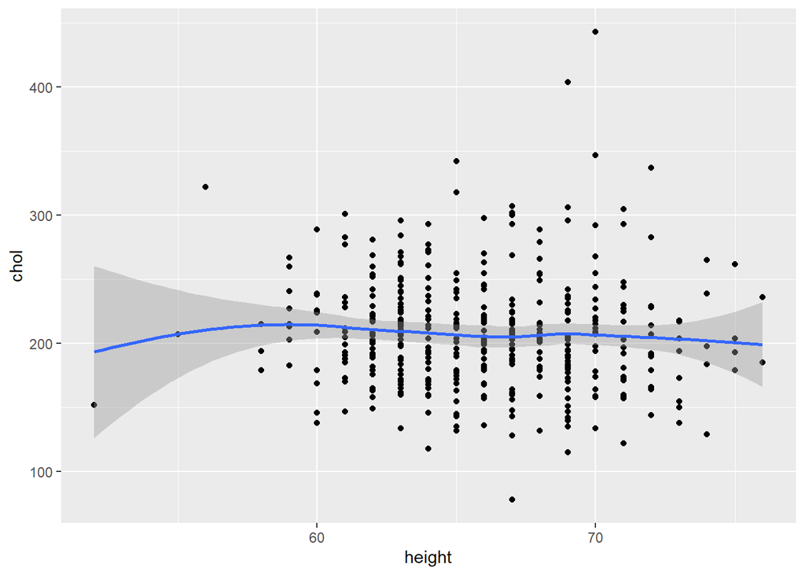

```r
ggplot(data = chlstrl) +
  geom_point(mapping = aes(x = height, y = chol)) +
  geom_smooth(mapping = aes(x = height, y = chol))
```

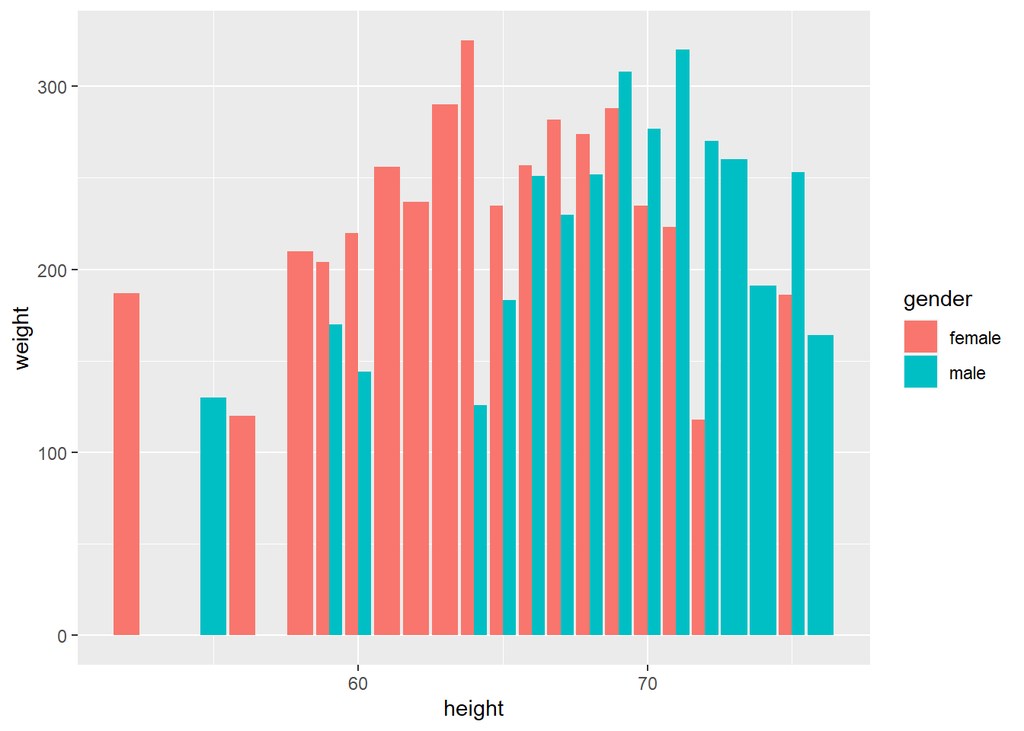

```r
ggplot(data = chlstrl, mapping = aes(x = height, y = weight, fill = gender)) +
  geom_bar(position = position_dodge(), stat = "identity", na.rm = TRUE)
```

4. weight

```r
min(chlstrl$weight, na.rm = TRUE)
```

```
## [1] 99
```

```r
max(chlstrl$weight, na.rm = TRUE)
```

```
## [1] 325
```

```r
mean(chlstrl$weight, na.rm = TRUE)
```

```
## [1] 177.592
```

```r
median(chlstrl$weight, na.rm = TRUE)
```

```
## [1] 172.5
```

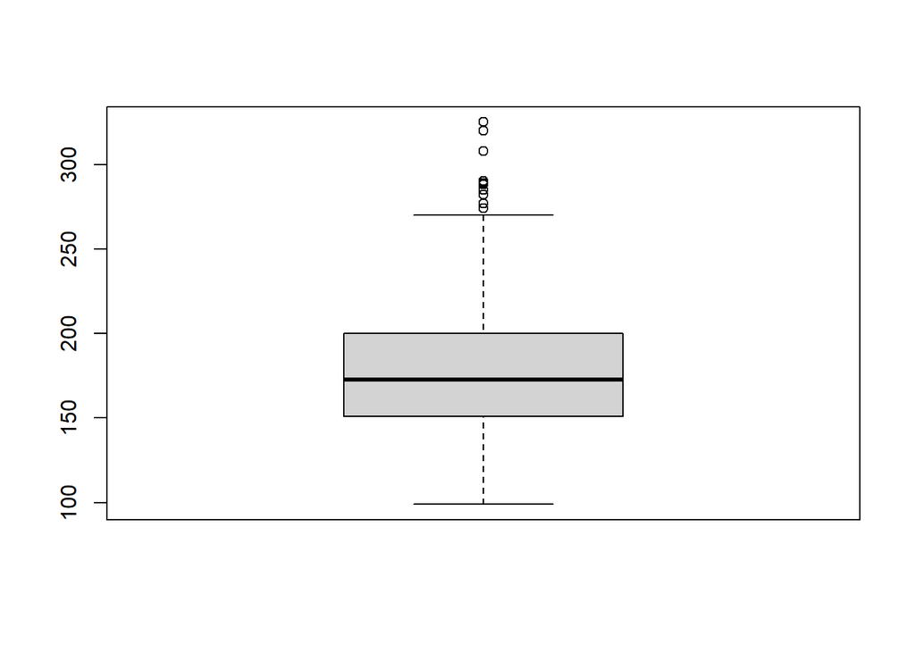

```r
bxp_weight = boxplot(chlstrl$weight)
```

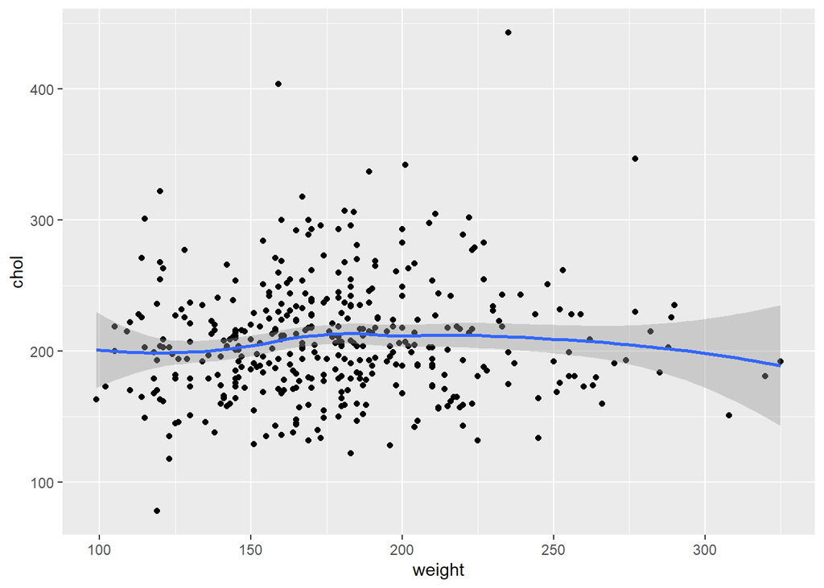

```r
ggplot(data = chlstrl) +
  geom_point(mapping = aes(x = weight, y = chol)) +
  geom_smooth(mapping = aes(x = weight, y = chol))
```

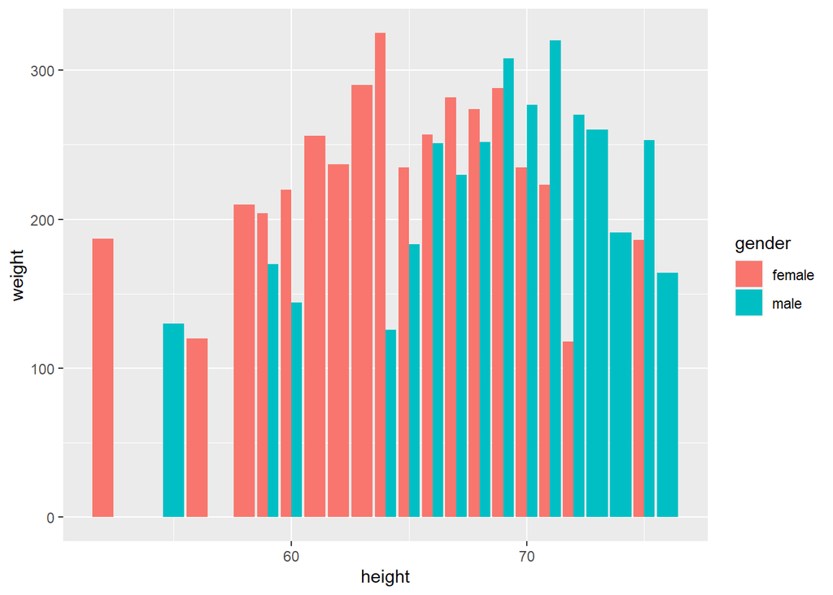

```r
ggplot(data = chlstrl, mapping = aes(x = height, y = weight, fill = gender)) +
  geom_bar(position = position_dodge(), stat = "identity", na.rm = TRUE)
```

5. waist

```r
min(chlstrl$waist, na.rm = TRUE)
```

```
## [1] 26
```

```r
max(chlstrl$waist, na.rm = TRUE)
```

```
## [1] 56
```

```r
mean(chlstrl$waist, na.rm = TRUE)
```

```
## [1] 37.90025
```

```r
median(chlstrl$waist, na.rm = TRUE)
```

```
## [1] 37
```

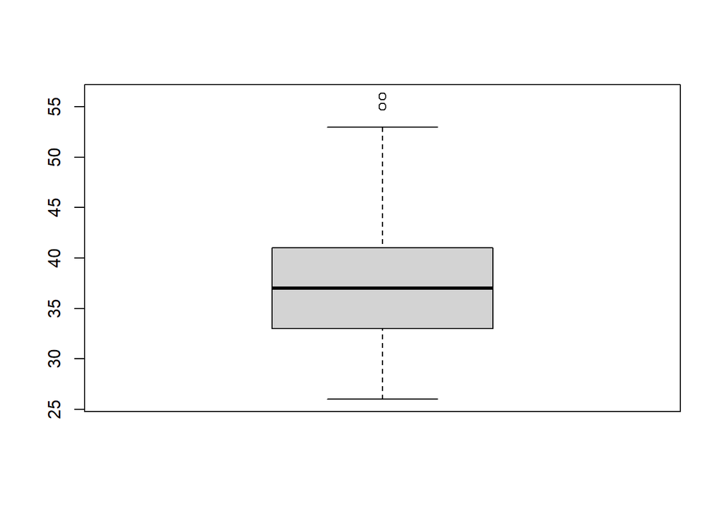

```r
bxp_waist = boxplot(chlstrl$waist)
```

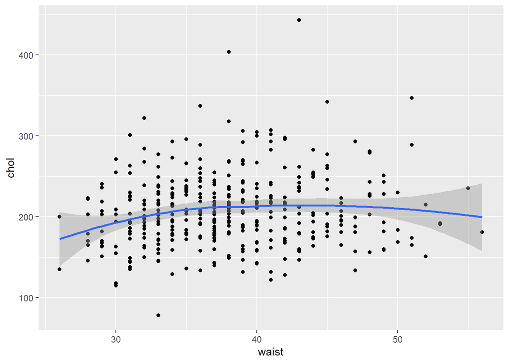

```r
ggplot(data = chlstrl) +
  geom_point(mapping = aes(x = waist, y = chol)) +
  geom_smooth(mapping = aes(x = waist, y = chol))
```

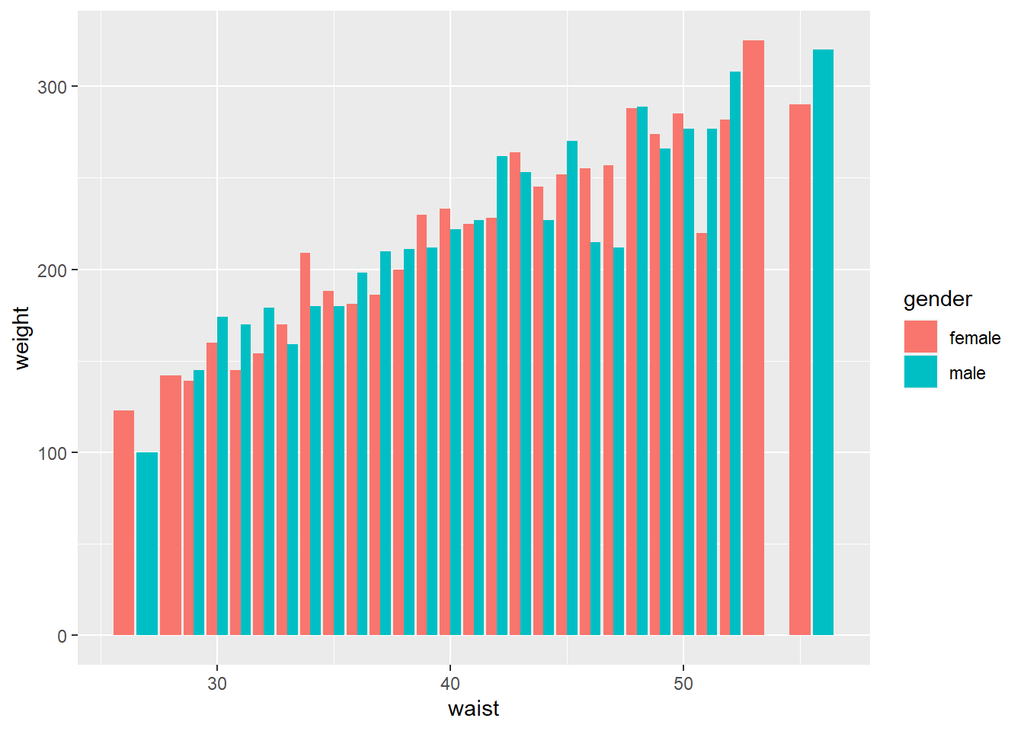

```r
ggplot(data = chlstrl, mapping = aes(x = waist, y = weight, fill = gender)) +
  geom_bar(position = position_dodge(), stat = "identity", na.rm = TRUE)
```

6. hip:

```r
min(chlstrl$hip, na.rm = TRUE)
```

```
## [1] 30
```

```r
max(chlstrl$hip, na.rm = TRUE)
```

```
## [1] 64
```

```r
mean(chlstrl$hip, na.rm = TRUE)
```

```
## [1] 43.0399
```

```r
median(chlstrl$hip, na.rm = TRUE)
```

```
## [1] 42
```

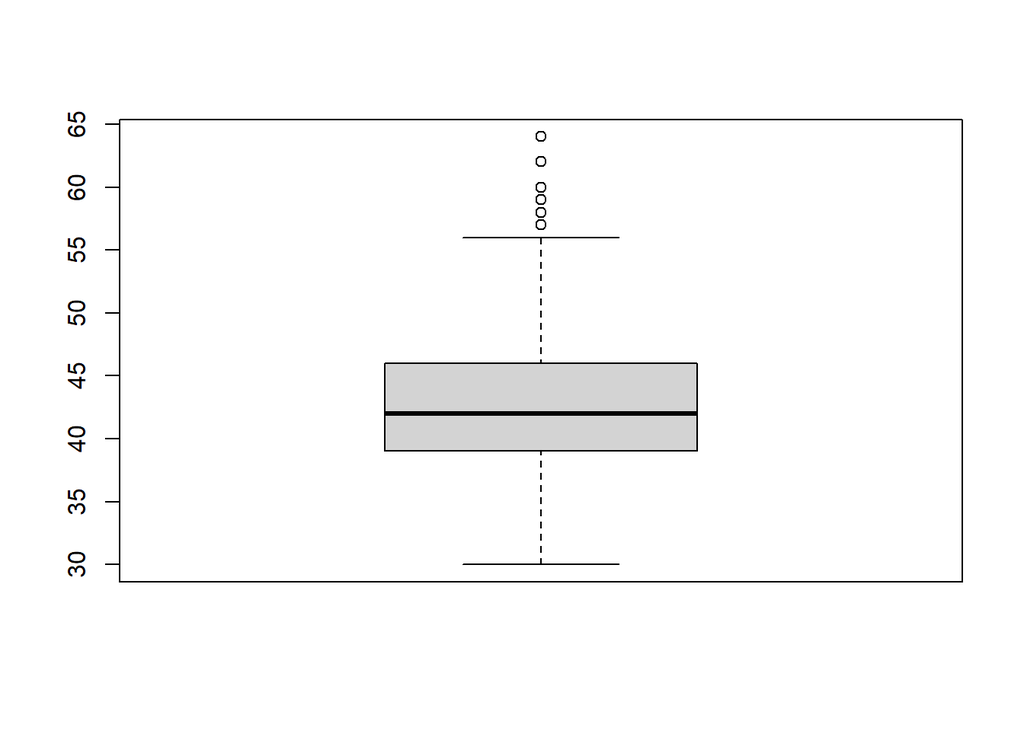

```r
bxp_hip = boxplot(chlstrl$hip)
```

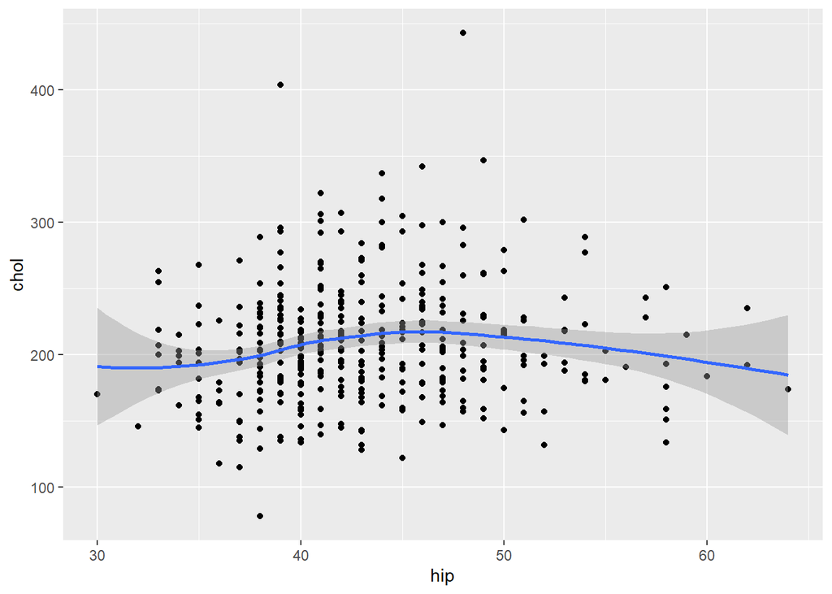

```r
ggplot(data = chlstrl) +
  geom_point(mapping = aes(x = hip, y = chol), na.rm = TRUE) +
  geom_smooth(mapping = aes(x = hip, y = chol))
```

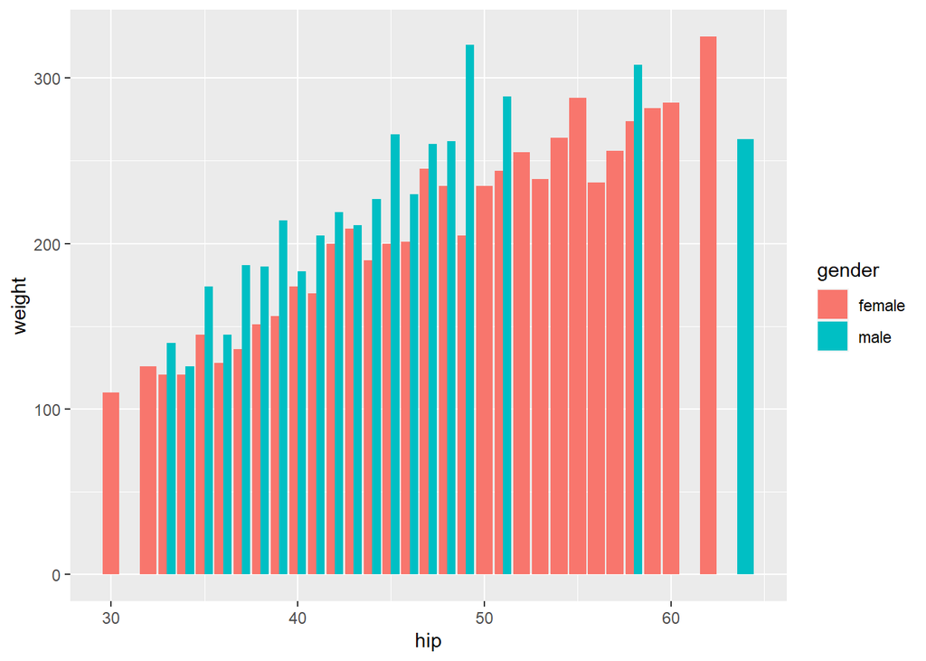

```r
ggplot(data = chlstrl, mapping = aes(x = hip, y = weight, fill = gender)) +
  geom_bar(position = position_dodge(), stat = "identity")
```

7. gender:

```r
(df1 <- table(chlstrl$gender))
```

```
##
## female   male
##    234    169
```

```r
(prop.table(df1))
```

```
##
##    female      male
## 0.5806452 0.4193548
```

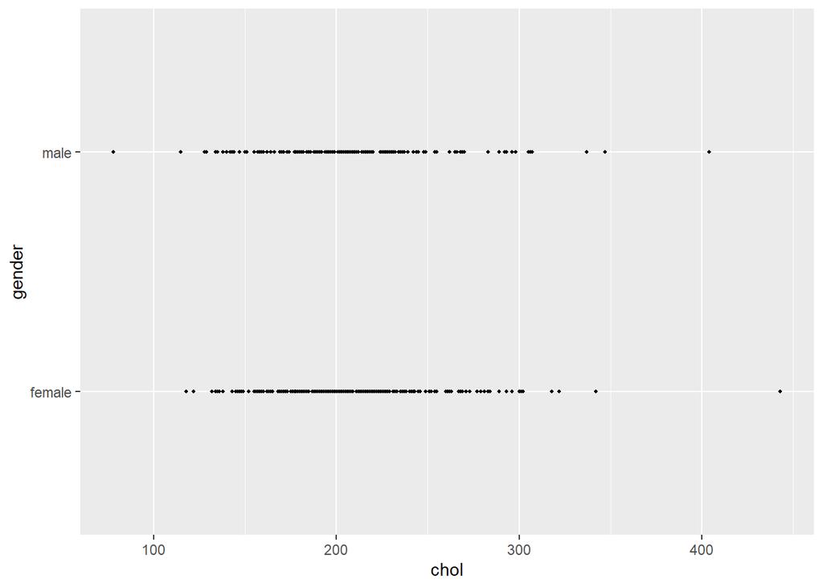

```r
ggplot(data = chlstrl) +
  geom_point(mapping = aes(x = chol, y = gender), size = 0.75)
```

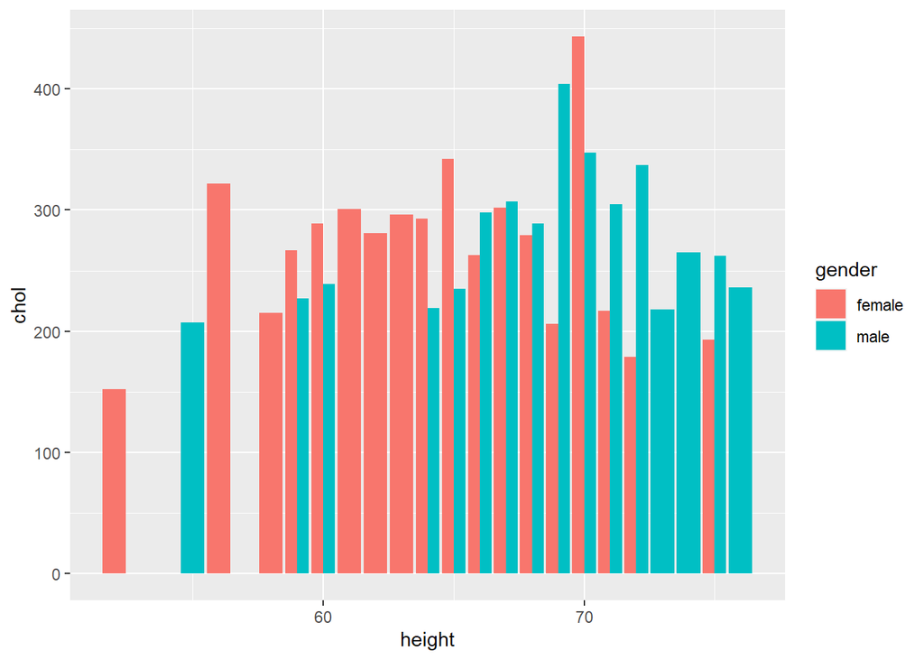

```r
ggplot(data = chlstrl, mapping = aes(x = height, y = chol, fill = gender)) +
  geom_bar(position = position_dodge(), stat = "identity")
```

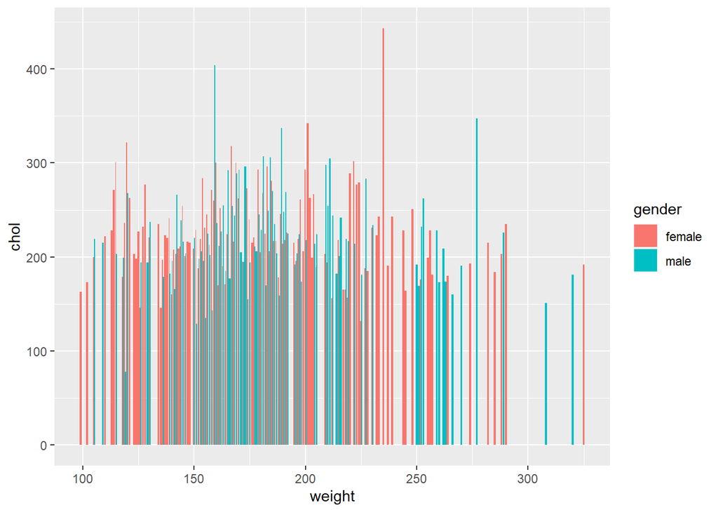

```r
ggplot(data = chlstrl, mapping = aes(x = weight, y = chol, fill = gender)) +
  geom_bar(position = position_dodge(), stat = "identity")
```

```r
pound_to_kg = 0.454
chlstrl$weight <- chlstrl$weight / pound_to_kg
head(chlstrl$weight)
```

```
## [1] 266.5198 480.1762 563.8767 262.1145 403.0837 418.5022
```

```r
inch_to_m = 0.0254
chlstrl$height <- chlstrl$height * inch_to_m
head(chlstrl$height)
```

```
## [1] 1.5748 1.6256 1.5494 1.7018 1.7272 1.8034
```

Añadir una nueva columna llamada BMI

```r
library(tidyverse)
chlstrl <- chlstrl %>%
  mutate(BMI = weight / height^2)
```

Crear una nueva columna llamada age group

```r
chlstrl <- chlstrl %>%
  mutate(
    ageGroup = case_when(
      age > 10 & age <= 40 ~ "(10-40]",
      age > 40 & age <= 70 ~ "(40-70]",
      age > 70 & age <= 100 ~ "(70-100]"
    )
  )
head(chlstrl$ageGroup)
```

```
## [1] "(40-70]" "(10-40]" "(40-70]" "(40-70]" "(40-70]" "(10-40]"
```

¿Cuantas observaciones hay en cada nivel de ageGroup?

```r
view(chlstrl)
chlstrl %>%
  group_by(ageGroup) %>%
  count(ageGroup)
```

```
## # A tibble: 3 x 2
## # Groups:   ageGroup [3]
##   ageGroup     n
##   <chr>    <int>
## 1 (10-40]    160
## 2 (40-70]    207
## 3 (70-100]    36
```

```r
chlstrl %>%
  filter(gender == "female") %>%
  group_by(ageGroup) %>%
  summarize(mean_fem_chol = mean(chol),
            mean_fem_bmi = mean(BMI, na.rm = TRUE))
```

```
## # A tibble: 3 x 3
##   ageGroup mean_fem_chol mean_fem_bmi
##   <chr>            <dbl>        <dbl>
## 1 (10-40]           189.         148.
## 2 (40-70]           221.         147.
## 3 (70-100]          230.         143.
```